# Face_mask_segmentation_Computer Vision_AIML_Aishik Sengupta

## The Problem Description:

In this hands-on project, the goal is to build a Face Mask Segmentation model which includes building a face detector to locate the position of a face in an image.

## Data Description:

### *WIDER Face Dataset*

**Link to the dataset:** https://drive.google.com/file/d/1rolp8QqyKkvxJwlBAPPGtG2f3JA7hMwk/view

**Acknowledgement for the datasets.** http://mmlab.ie.cuhk.edu.hk/projects/WIDERFace/

**Mobile Net paper:** https://arxiv.org/pdf/1704.04861.pdf

## Objective:

In this problem, we use "Transfer Learning" of an Image Segmentation model to detect any object according to the problem in hand. Here, we are particularly interested in segmenting faces in a given image: Steps and tasks

1. Load the dataset given in form .npy format.
2. Create Features(images) and labels(mask) using that data.
3. Load the pre-trained model and weights.
4. Create a model using the above model.
5. Define the Dice Coefficient and Loss function.
6. Compile and fit the model.
7. Evaluate the model.

```python
import numpy as np
import cv2
from tensorflow.keras.applications.mobilenet import MobileNet,preprocess_input
from tensorflow.keras.layers import Concatenate, UpSampling2D, Conv2D, Reshape
from tensorflow.keras.models import Model
from tensorflow.keras.losses import binary_crossentropy
from tensorflow.keras.backend import log, epsilon
from tensorflow.keras.callbacks import ModelCheckpoint, EarlyStopping, ReduceLROnPlateau
from tensorflow.keras.optimizers import Adam
import matplotlib.pyplot as plt
```

```python
%tensorflow_version 2.x
import tensorflow
tensorflow.__version__
```

```
'2.3.0'
```

#### Mount Google drive if you are using google colab

```python
from google.colab import drive
drive.mount('/content/drive')
```

### Change current working directory to project folder

```python
import os
os.chdir('/content/drive/My Drive/AIML_Colab/Datasets/Wider Face Dataset from GL/')
```

### Load the "images.npy" file

```python
data = np.load('images.npy', allow_pickle = True)
```

```python
data.shape # checking the dimensions
```

```
(409, 2)
```

```python
type(data) #checking the type
```

```
numpy.ndarray
```

```python
# Image Matrix data
print(data[10][0])
```

```
[[[2 2 2]
  [2 2 2]
  [2 2 2]
  ...
  [0 0 0]
  [0 0 0]
  [0 0 0]]

 [[2 2 2]
  [2 2 2]
  [2 2 2]
  ...
  [0 0 0]
  [0 0 0]
  [0 0 0]]

 [[2 2 2]
  [2 2 2]
  [2 2 2]
  ...
  [0 0 0]
  [0 0 0]
  [0 0 0]]

 ...

 [[0 0 0]
  [0 0 0]
  [0 0 0]
  ...
  [5 5 5]
  [6 6 6]
  [6 6 6]]

 [[0 0 0]
  [0 0 0]
  [0 0 0]
  ...
  [5 5 5]
  [6 6 6]
  [6 6 6]]

 [[0 0 0]
  [0 0 0]
  [0 0 0]
  ...
  [5 5 5]
  [5 5 5]
  [5 5 5]]]
```

```python
# Image Mask data
print(data[10][1])
```

```
[{'label': ['Face'], 'notes': '', 'points': [{'x': 0.48, 'y': 0.10385756676557864}, {'x': 0.7716666666666666, 'y': 0.6795252225519288}], 'imageWidth': 600, 'imageHeight': 337}]
```

### Set image dimensions

- Initialize image height, image width with value: 224

```python
IMAGE_WIDTH = 224
IMAGE_HEIGHT = 224
```

```python
# checking few imagse dimensions
print(data[0][0].shape)
print(data[1][0].shape)
print(data[2][0].shape)
print(data[3][0].shape)
print(data[4][0].shape)
print(data[5][0].shape)
print(data[6][0].shape)
print(data[7][0].shape)
print(data[8][0].shape)
print(data[9][0].shape)
```

```
(333, 650, 3)
(697, 1280, 4)
(240, 460, 3)
(291, 600, 4)
(326, 580, 3)
(500, 500, 3)
(357, 634, 3)
(450, 800, 3)
(1026, 625, 3)
(274, 184, 3)
```

### Create features and labels

- Here feature is the image
- The label is the mask
- Images will be stored in "imgs" array
- Masks will be stored in "masks" array

```python
masks = np.zeros((int(data.shape[0]), IMAGE_HEIGHT, IMAGE_WIDTH))
imgs = np.zeros((int(data.shape[0]), IMAGE_HEIGHT, IMAGE_WIDTH, 3))
for index in range(data.shape[0]):
    img = data[index][0]
    img = cv2.resize(img, dsize=(IMAGE_HEIGHT, IMAGE_WIDTH), interpolation=cv2.INTER_CUBIC)
    try:
      img = img[:, :, :3]
    except:
      print(f'Exception caught for image at index {index}') # this image is absolutely blank, opaque
      continue
    imgs[index] = preprocess_input(np.array(img, dtype=np.float32))
    for i in data[index][1]:
        x1 = int(i["points"][0]['x'] * IMAGE_WIDTH)
        x2 = int(i["points"][1]['x'] * IMAGE_WIDTH)
        y1 = int(i["points"][0]['y'] * IMAGE_HEIGHT)
        y2 = int(i["points"][1]['y'] * IMAGE_HEIGHT)
        masks[index][y1:y2, x1:x2] = 1
```

```
Exception caught for image at index 272
```

### Check the dimensions of the images and maks after interpolation

```python
print(imgs.shape)
```

```
(409, 224, 224, 3)
```

```python
print(masks.shape)
```

```
(409, 224, 224)
```

### Print a sample image and image array

```
Clipping input data to the valid range for imshow with RGB data ([0..1] for floats or [0..255] for integers).
```

```
[[[ 0.5529412   0.43529415 -0.09019607]
  [ 0.6156863   0.49803925 -0.02745098]
  [ 0.62352943  0.50588238 -0.01960784]
  ...
  [ 0.74117649  0.34117651 -0.48235291]
  [ 0.56078434  0.14509809 -0.67058825]
  [ 0.60784316  0.16078436 -0.63137257]]

 [[ 0.57647061  0.45882356 -0.04313725]
  [ 0.63921571  0.52156866  0.01176476]
  [ 0.57647061  0.45882356 -0.05098039]
  ...
  [ 0.70980394  0.3176471  -0.49803919]
  [ 0.66274512  0.24705887 -0.56862748]
  [ 0.6156863   0.16078436 -0.63137257]]

 [[ 0.63921571  0.52156866  0.01176476]
  [ 0.63921571  0.52156866  0.01176476]
  [ 0.5529412   0.43529415 -0.0745098 ]
  ...
  [ 0.73333335  0.35686278 -0.4588235 ]
  [ 0.67843139  0.27058828 -0.52156866]
  [ 0.69411767  0.24705887 -0.56078434]]

 ...

 [[-0.5529412  -0.96862745 -0.96862745]
  [-0.48235291 -0.98431373 -0.98431373]
  [-0.48235291 -0.98431373 -1.        ]
  ...
  [-0.96078432 -0.99215686 -0.99215686]
  [-0.9137255  -0.96078432 -0.95294118]
  [-0.93725491 -0.99215686 -0.98431373]]

 [[-0.52941179 -0.99215686 -1.        ]
  [-0.47450978 -1.         -1.        ]
  [-0.44313723 -0.98431373 -0.99215686]
  ...
  [-0.8509804  -0.96078432 -0.93725491]
  [-0.89803922 -1.         -0.98431373]
  [-0.9137255  -0.99215686 -0.98431373]]

 [[-0.47450978 -0.97647059 -0.97647059]
  [-0.49019605 -1.         -1.        ]
  [-0.38039213 -0.95294118 -0.96078432]
  ...
  [-0.82745099 -0.94509804 -0.92156863]
  [-0.95294118 -1.         -1.        ]
  [-0.99215686 -1.         -1.        ]]]
```

[figure not shown]

```python
n = 100
print(imgs[n])
plt.imshow(imgs[n])
```

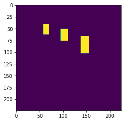

```python
plt.imshow(masks[n])
```

### Splitting into train and test , to evaluate later on a test set

```python
# train n test

x_test=np.zeros((9,224,224,3))
test_mask=np.zeros((9,224,224))
x_train=np.zeros((400,224,224,3))
train_mask=np.zeros((400,224,224))
index=[]
j=0
k=0
for i in range(imgs.shape[0]):
  if i>=400:
    x_test[j]=imgs[i]
    test_mask[j]=masks[i]
    index.append(i)
    j+=1
  else:
    x_train[k]=imgs[i]
    train_mask[k]=masks[i]
    k+=1
```

## Create the model (10 marks)

- Add MobileNet as model with below parameter values
  - input_shape: IMAGE_HEIGHT, IMAGE_WIDTH, 3
  - include_top: False
  - alpha: 1.0
  - weights: "imagenet"
- Add UNET architecture layers
  - This is the trickiest part of the project, you need to research and implement it correctly

```python
def create_model(trainable=True):
    model = MobileNet(input_shape=(IMAGE_HEIGHT, IMAGE_WIDTH, 3), include_top=False, alpha=1.0, weights="imagenet")
    for layer in model.layers:
        layer.trainable = trainable

    # Add all the UNET layers here
    block1 = model.get_layer("conv_pw_1_relu").output
    block2 = model.get_layer("conv_pw_3_relu").output
    block3 = model.get_layer("conv_pw_5_relu").output
    block4 = model.get_layer("conv_pw_11_relu").output
    block5 = model.get_layer("conv_pw_13_relu").output

    x = Concatenate()([UpSampling2D()(block5), block4])
    x = Concatenate()([UpSampling2D()(x), block3])
    x = Concatenate()([UpSampling2D()(x), block2])
    x = Concatenate()([UpSampling2D()(x), block1])
    x = UpSampling2D()(x)

    x = Conv2D(1, kernel_size=1, activation="sigmoid")(x)
    x = Reshape((IMAGE_HEIGHT, IMAGE_WIDTH))(x)

    return Model(inputs=model.input, outputs=x)
```

### Define dice coefficient function

```python
def dice_coefficient(y_true, y_pred):
    numerator = 2 * tensorflow.reduce_sum(y_true * y_pred)
    denominator = tensorflow.reduce_sum(y_true + y_pred)

    return numerator / (denominator + tensorflow.keras.backend.epsilon())
```

### Define loss

```python
def loss(y_true, y_pred):
    return binary_crossentropy(y_true, y_pred) - tensorflow.keras.backend.log(dice_coefficient(y_true, y_pred) + tensorflow.keras.backend.epsilon())
```

### Call the create_model function

```python
model = create_model(False)
model.summary()
```

```
Downloading data from https://storage.googleapis.com/tensorflow/keras-applications/mobilenet/mobilenet_1_0_224_tf_no_top.h5
Model: "functional_1"
__________________________________________________________________________________________________
Layer (type)                    Output Shape         Param #     Connected to
==================================================================================================
input_1 (InputLayer)            [(None, 224, 224, 3) 0
__________________________________________________________________________________________________
conv1_pad (ZeroPadding2D)       (None, 225, 225, 3)  0           input_1[0][0]
__________________________________________________________________________________________________
conv1 (Conv2D)                  (None, 112, 112, 32) 864         conv1_pad[0][0]
__________________________________________________________________________________________________
conv1_bn (BatchNormalization)   (None, 112, 112, 32) 128         conv1[0][0]
__________________________________________________________________________________________________
conv1_relu (ReLU)               (None, 112, 112, 32) 0           conv1_bn[0][0]
__________________________________________________________________________________________________
conv_dw_1 (DepthwiseConv2D)     (None, 112, 112, 32) 288         conv1_relu[0][0]
__________________________________________________________________________________________________
conv_dw_1_bn (BatchNormalizatio (None, 112, 112, 32) 128         conv_dw_1[0][0]
__________________________________________________________________________________________________
conv_dw_1_relu (ReLU)           (None, 112, 112, 32) 0           conv_dw_1_bn[0][0]
__________________________________________________________________________________________________
conv_pw_1 (Conv2D)              (None, 112, 112, 64) 2048        conv_dw_1_relu[0][0]
__________________________________________________________________________________________________
conv_pw_1_bn (BatchNormalizatio (None, 112, 112, 64) 256         conv_pw_1[0][0]
__________________________________________________________________________________________________
conv_pw_1_relu (ReLU)           (None, 112, 112, 64) 0           conv_pw_1_bn[0][0]
__________________________________________________________________________________________________
conv_pad_2 (ZeroPadding2D)      (None, 113, 113, 64) 0           conv_pw_1_relu[0][0]
__________________________________________________________________________________________________
conv_dw_2 (DepthwiseConv2D)     (None, 56, 56, 64)   576         conv_pad_2[0][0]
__________________________________________________________________________________________________
conv_dw_2_bn (BatchNormalizatio (None, 56, 56, 64)   256         conv_dw_2[0][0]
__________________________________________________________________________________________________
conv_dw_2_relu (ReLU)           (None, 56, 56, 64)   0           conv_dw_2_bn[0][0]
__________________________________________________________________________________________________
conv_pw_2 (Conv2D)              (None, 56, 56, 128)  8192        conv_dw_2_relu[0][0]
__________________________________________________________________________________________________
conv_pw_2_bn (BatchNormalizatio (None, 56, 56, 128)  512         conv_pw_2[0][0]
__________________________________________________________________________________________________
conv_pw_2_relu (ReLU)           (None, 56, 56, 128)  0           conv_pw_2_bn[0][0]
```

[output cut: 154 more lines]

```
up_sampling2d_3 (UpSampling2D)  (None, 112, 112, 192 0           concatenate_2[0][0]
__________________________________________________________________________________________________
concatenate_3 (Concatenate)     (None, 112, 112, 198 0           up_sampling2d_3[0][0]
                                                                 conv_pw_1_relu[0][0]
__________________________________________________________________________________________________
up_sampling2d_4 (UpSampling2D)  (None, 224, 224, 198 0           concatenate_3[0][0]
__________________________________________________________________________________________________
conv2d (Conv2D)                 (None, 224, 224, 1)  1985        up_sampling2d_4[0][0]
__________________________________________________________________________________________________
reshape (Reshape)               (None, 224, 224)     0           conv2d[0][0]
==================================================================================================
Total params: 3,230,849
Trainable params: 1,985
Non-trainable params: 3,228,864
__________________________________________________________________________________________________
```

### Compile the model (3 marks)

- Complie the model using below parameters
  - loss: use the loss function defined above
  - optimizers: use Adam optimizer
  - metrics: use dice_coefficient function defined above

```python
optimizer = Adam(lr=1e-4, beta_1=0.9, beta_2=0.999, epsilon=None, decay=0.0, amsgrad=False)
model.compile(loss=loss, optimizer=optimizer, metrics=[dice_coefficient])
```

### Define checkpoint and earlystopping

```python
checkpoint = ModelCheckpoint("model-{loss:.2f}.h5", monitor="loss", verbose=1, save_best_only=True,
                             save_weights_only=True, mode="min", save_freq=1)
stop = EarlyStopping(monitor="loss", patience=5, mode="min")
reduce_lr = ReduceLROnPlateau(monitor="loss", factor=0.2, patience=5, min_lr=1e-6, verbose=1, mode="min")
```

### Fit the model (3 marks)

- Fit the model using below parameters
  - epochs: you can decide
  - batch_size: 1
  - callbacks: checkpoint, reduce_lr, stop

```python
model.fit(x_train, train_mask, epochs = 100, batch_size = 1, verbose = 2 ,callbacks=[checkpoint, reduce_lr, stop])
```

[output not shown]

[output cut: 4939 more lines]

```

Epoch 00088: loss did not improve from 0.30538

Epoch 00088: loss did not improve from 0.30538

Epoch 00088: loss did not improve from 0.30538

Epoch 00088: loss did not improve from 0.30538

Epoch 00088: loss did not improve from 0.30538

Epoch 00088: loss did not improve from 0.30538

Epoch 00088: ReduceLROnPlateau reducing learning rate to 1.9999999494757503e-05.
400/400 - 10s - loss: 0.6674 - dice_coefficient: 0.6534
```

```
<tensorflow.python.keras.callbacks.History at 0x7f41c9de8630>
```

```python
model.evaluate(x_test,test_mask,batch_size=10)
```

```
[0.5878678560256958, 0.6654328107833862]
```

### Checking an actual image from test set

```
Clipping input data to the valid range for imshow with RGB data ([0..1] for floats or [0..255] for integers).
```

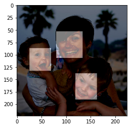

```python
# Actual image
n = 0
plt.imshow(x_test[n])
plt.imshow(test_mask[n],cmap='gray',alpha=0.5)
```

### Get the predicted mask for a sample image

```python
n = 0
sample_image = x_test[n]
pred_mask = cv2.resize(1.0*(model.predict(x=np.array([sample_image]))[0] > 0.5), (IMAGE_WIDTH,IMAGE_HEIGHT))
```

### Impose the mask on the image

```
Clipping input data to the valid range for imshow with RGB data ([0..1] for floats or [0..255] for integers).
```

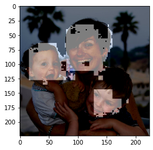

```python
plt.imshow(x_test[n])
plt.imshow(pred_mask,cmap='gray',alpha=0.5)
```

```
Clipping input data to the valid range for imshow with RGB data ([0..1] for floats or [0..255] for integers).
```

[figure not shown]

```python
# Actual image
n = 50
plt.imshow(x_train[n])
plt.imshow(train_mask[n],cmap='gray',alpha=0.6)
```

```python
n = 50
sample_image = x_train[n]
pred_mask = cv2.resize(1.0*(model.predict(x=np.array([sample_image]))[0] > 0.5), (IMAGE_WIDTH,IMAGE_HEIGHT))
```

```
Clipping input data to the valid range for imshow with RGB data ([0..1] for floats or [0..255] for integers).
```

[figure not shown]

```python
plt.imshow(x_train[n])
plt.imshow(pred_mask,cmap='gray',alpha=0.6)
```

## I would say the results are satisfactory, and obvious it can be improved. Need to check for other networks. More importantly, we need the full WIDER FACE dataset for training. This is a very small data set.